# Statistical Analysis of Functional Capacity and Quality of Life in Pediatric Patients with Marfan Syndrome

Chloé Laignel-Granier

2026-04-14

# Setup and loading of required R packages

```r
packages <- c("readxl", "dplyr", "gridExtra")

for (pkg in packages) {
  if (!require(pkg, character.only = TRUE)) {
    install.packages(pkg)
    library(pkg, character.only = TRUE)
  }
}
```

# Step 6. Import datasets clean in R

```r
# Load package
library(readxl)

# Import datasets
included_data <- read_excel("../data/data_clean.xlsx")
excluded_data <- read_excel("../data/data_excluded.xlsx")

# Check structure
str(included_data)
```

```
## tibble [20 × 24] (S3: tbl_df/tbl/data.frame)
##  $ id                               : num [1:20] 1 3 4 6 8 9 10 11 13 14 ...
##  $ age                              : num [1:20] 10.5 10.7 17.4 15.4 12.7 ...
##  $ sexe                             : chr [1:20] "M" "M" "F" "M" ...
##  $ weight_kg                        : num [1:20] 47.8 26 69 66.6 53 55.3 49 24 43 32 ...
##  $ height_cm                        : num [1:20] 163 142 186 188 166 ...
##  $ bmi_kg_cm2                       : num [1:20] 18.1 12.9 20.1 18.8 19.2 ...
##  $ 6minwt_distance_traveled_m_before: num [1:20] 660 556 588 635 640 593 551 516 625 526 ...
##  $ 6minwt_distance_traveled_m_after : num [1:20] 737 618 692 697 598 682 744 682 575 585 ...
##  $ vat_before                       : num [1:20] 29.9 38.2 29 33.6 32.5 ...
##  $ vat_after                        : num [1:20] 40 41.5 45.1 52.5 36.9 ...
##  $ pedsql_totalself_before          : num [1:20] 69.6 92.4 52.2 87 66.3 ...
##  $ pedsql_totalself_after           : num [1:20] 75 92.4 57.6 95.7 82.6 ...
##  $ pedsql_santeself_before          : num [1:20] 75 96.9 46.9 93.8 71.9 ...
##  $ pedsql_santeself_after           : num [1:20] 71.9 96.9 53.1 100 100 ...
##  $ pedsql_emotionself_before        : num [1:20] 60 85 50 70 70 55 90 85 75 60 ...
##  $ pedsql_emotionself_after         : num [1:20] 70 85 55 90 75 85 100 95 85 60 ...
##  $ pedsql_relationself_before       : num [1:20] 65 100 50 90 70 60 100 90 70 100 ...
##  $ pedsql_relationself_after        : num [1:20] 85 100 55 100 85 90 100 100 75 80 ...
##  $ pedsql_ecoleself_before          : num [1:20] 75 85 65 90 50 65 85 75 90 80 ...
##  $ pedsql_ecoleself_after           : num [1:20] 75 85 70 90 60 85 95 85 75 50 ...
##  $ pedsql_psycosocialself_before    : num [1:20] 66.7 90 55 83.3 63.3 ...
##  $ pedsql_psycosocialself_after     : num [1:20] 76.7 90 60 93.3 73.3 ...
##  $ pedsql_physiqueself_before       : num [1:20] 75 96.9 46.9 93.8 71.9 ...
##  $ pedsql_physiqueself_after        : num [1:20] 71.9 96.9 53.1 100 100 ...
```

```r
str(excluded_data)
```

```
## tibble [8 × 24] (S3: tbl_df/tbl/data.frame)
##  $ id                               : num [1:8] 2 5 7 12 16 17 25 27
##  $ age                              : num [1:8] 14.4 19 12.3 14.2 10 ...
##  $ sexe                             : chr [1:8] "F" "F" "M" "F" ...
##  $ weight_kg                        : num [1:8] 43 54.8 35 62 32 62.7 42 71
##  $ height_cm                        : num [1:8] 174 177 167 171 150 168 182 183
##  $ bmi_kg_cm2                       : num [1:8] 14.2 17.5 12.5 21.2 14.2 ...
##  $ 6minwt_distance_traveled_m_before: num [1:8] 598 583 635 634 593 568 580 588
##  $ 6minwt_distance_traveled_m_after : logi [1:8] NA NA NA NA NA NA ...
##  $ vat_before                       : num [1:8] 38.7 40 32.2 56.5 40.5 ...
##  $ vat_after                        : logi [1:8] NA NA NA NA NA NA ...
##  $ pedsql_totalself_before          : num [1:8] 87 76.1 75 91.3 83.7 ...
##  $ pedsql_totalself_after           : num [1:8] NA 70.7 NA 75 NA ...
##  $ pedsql_santeself_before          : num [1:8] 87.5 62.5 75 93.8 84.4 ...
##  $ pedsql_santeself_after           : num [1:8] NA 53.1 NA 78.1 NA ...
##  $ pedsql_emotionself_before        : num [1:8] 80 75 95 90 80 40 35 45
##  $ pedsql_emotionself_after         : num [1:8] NA 65 NA 65 NA NA NA NA
##  $ pedsql_relationself_before       : num [1:8] 85 75 55 90 90 20 35 30
##  $ pedsql_relationself_after        : num [1:8] NA 75 NA 75 NA NA NA NA
##  $ pedsql_ecoleself_before          : num [1:8] 95 100 75 90 80 50 30 50
##  $ pedsql_ecoleself_after           : num [1:8] NA 100 NA 80 NA NA NA NA
##  $ pedsql_psycosocialself_before    : num [1:8] 86.7 83.3 75 90 83.3 ...
##  $ pedsql_psycosocialself_after     : num [1:8] NA 80 NA 73.3 NA ...
##  $ pedsql_physiqueself_before       : num [1:8] 87.5 62.5 75 93.8 84.4 ...
##  $ pedsql_physiqueself_after        : num [1:8] NA 53.1 NA 78.1 NA ...
```

The cleaned datasets were imported into R for statistical analysis. Separate datasets were used for included patients, forming the main analytical sample, and excluded patients, allowing the evaluation of potential selection bias.

# Step 7. Descriptive statistics of included and excluded patients at baseline

```r
library(dplyr)
library(gridExtra)
library(grid)

# Descriptive statistics of included and excluded patients at baseline

# Fonction descriptive
describe <- function(x) {
  data.frame(
    Statistic = c("Mean", "SD", "Median", "Q1", "Q3"),
    Value = c(
      mean(x, na.rm = TRUE),
      sd(x, na.rm = TRUE),
      median(x, na.rm = TRUE),
      quantile(x, 0.25, na.rm = TRUE),
      quantile(x, 0.75, na.rm = TRUE)
    )
  )
}

vars <- c("age", "weight_kg", "height_cm", "bmi_kg_cm2",
          "6minwt_distance_traveled_m_before",
          "vat_before",
          "pedsql_totalself_before")

labels <- c(
  "Age (years)",
  "Weight (kg)",
  "Height (cm)",
  "BMI (kg/m²)",
  "6MWT distance (m)",
  "VAT (% predicted)",
  "PedsQL score (0–100)"
)

# Total sample sizes
n_inc_total <- nrow(included_data)
n_exc_total <- nrow(excluded_data)

table_list <- list()

for(i in seq_along(vars)) {

  var <- vars[i]

  x <- included_data[[var]]
  y <- excluded_data[[var]]

  x_clean <- x[!is.na(x)]
  y_clean <- y[!is.na(y)]

  p_val <- round(wilcox.test(x_clean, y_clean, exact = FALSE)$p.value, 3)
  p_val <- paste0(p_val, "*")

  inc <- describe(x)
  exc <- describe(y)

  df <- data.frame(
    Variable = c(labels[i], rep("", 4)),
    Statistic = inc$Statistic,
    Included = round(inc$Value, 1),
    Excluded = round(exc$Value, 1),
    p_value = c(p_val, rep("", 4))
  )

  table_list[[i]] <- df
}

table_final <- do.call(rbind, table_list)

# Sex comparison (Fisher's test)
p_sexe <- fisher.test(table(
  c(included_data$sexe, excluded_data$sexe),
  c(rep("Included", nrow(included_data)),
    rep("Excluded", nrow(excluded_data)))
))$p.value

p_sexe <- paste0(round(p_sexe, 3), "†")

sexe_inc <- table(included_data$sexe)
sexe_exc <- table(excluded_data$sexe)

sex_df <- data.frame(
  Variable = c("Sex (M/F)", rep("", length(sexe_inc)-1)),
  Statistic = names(sexe_inc),
  Included = as.numeric(sexe_inc),
  Excluded = as.numeric(sexe_exc),
  p_value = c(p_sexe, rep("", length(sexe_inc)-1))
)

table_final <- rbind(table_final, sex_df)

# Rename columns with total sample size
colnames(table_final)[3:4] <- c(
  paste0("Included (n=", n_inc_total, ")"),
  paste0("Excluded (n=", n_exc_total, ")")
)

table_final
```

```
##                Variable Statistic Included (n=20) Excluded (n=8) p_value
## 1           Age (years)      Mean            12.4           13.8  0.297*
## 2                              SD             4.0            2.8
## 3                          Median            11.2           13.8
## 4                              Q1             9.8           12.0
## 5                              Q3            15.8           14.7
## 6           Weight (kg)      Mean            45.6           50.3  0.401*
## 7                              SD            17.9           14.3
## 8                          Median            48.4           48.9
## 9                              Q1            27.8           40.2
## 10                             Q3            56.1           62.2
## 11          Height (cm)      Mean           163.9          171.5  0.373*
## 12                             SD            22.0           10.5
## 13                         Median           165.0          172.5
## 14                             Q1           142.0          167.8
```

[output cut: 23 more lines]

```r
# Export table as image
n_rows <- nrow(table_final)

png(
  "../figures/Table_1_Comparison_of_included_and_excluded_patients_at_baseline.png",
  width = 900,
  height = 2 + n_rows * 42,
  res = 150
)

tg <- tableGrob(
  table_final,
  rows = NULL,
  theme = ttheme_minimal(
    core = list(
      fg_params = list(fontsize = 9)
    ),
    colhead = list(
      fg_params = list(fontsize = 10, fontface = "bold")
    )
  )
)

grid.arrange(
  textGrob(
    "Table 1. Comparison of included and excluded patients at baseline",
    gp = gpar(fontsize = 10, fontface = "bold")
  ),
  tg,
  textGrob(
    "* Mann–Whitney test; † Fisher’s test",
    gp = gpar(fontsize = 8, fontface = "italic")
  ),
  ncol = 1,
  heights = c(0.2, 5, 0.3)
)

dev.off()
```

Descriptive statistics were calculated for both included and excluded patients to assess potential selection bias. Continuous variables were summarized using mean ± standard deviation and median values. Group comparisons were performed using the Mann–Whitney U test for quantitative variables and Fisher’s exact test for qualitative variables.

A summary table was constructed to compare baseline characteristics between groups, with results formatted for clarity. The table was displayed in the R Markdown document and exported as a PNG for reporting.

# Step 9. Comparison of 6MWT Before and After Intervention.

Due to the small sample size and the potential non-normal distribution of the data, a non-parametric paired Wilcoxon signed-rank test was used to compare 6-minute walk distance before and after the intervention.

A paired comparison of 6-minute walk distance before and after the intervention was performed in included patients.

```r
# Paired Wilcoxon test
wilcox_test <- wilcox.test(
  included_data$`6minwt_distance_traveled_m_after`,
  included_data$`6minwt_distance_traveled_m_before`,
  paired = TRUE,
  exact = TRUE
)
wilcox_test
```

```
##
##  Wilcoxon signed rank test with continuity correction
##
## data:  included_data$`6minwt_distance_traveled_m_after` and included_data$`6minwt_distance_traveled_m_before`
## V = 170, p-value = 0.016
## alternative hypothesis: true location shift is not equal to 0
```

```r
# Export Wilcoxon test results to a text file
sink("../results/wilcoxon_test_results.txt")
cat("Paired Wilcoxon Test (6MWT before vs after)\n\n")
print(wilcox_test)
sink()
```

# Step 10. Visualization of the 6 dimensions of the PedsQL self-questionnaire after 6 months

## Boxplots of PedsQL scores before and after the intervention

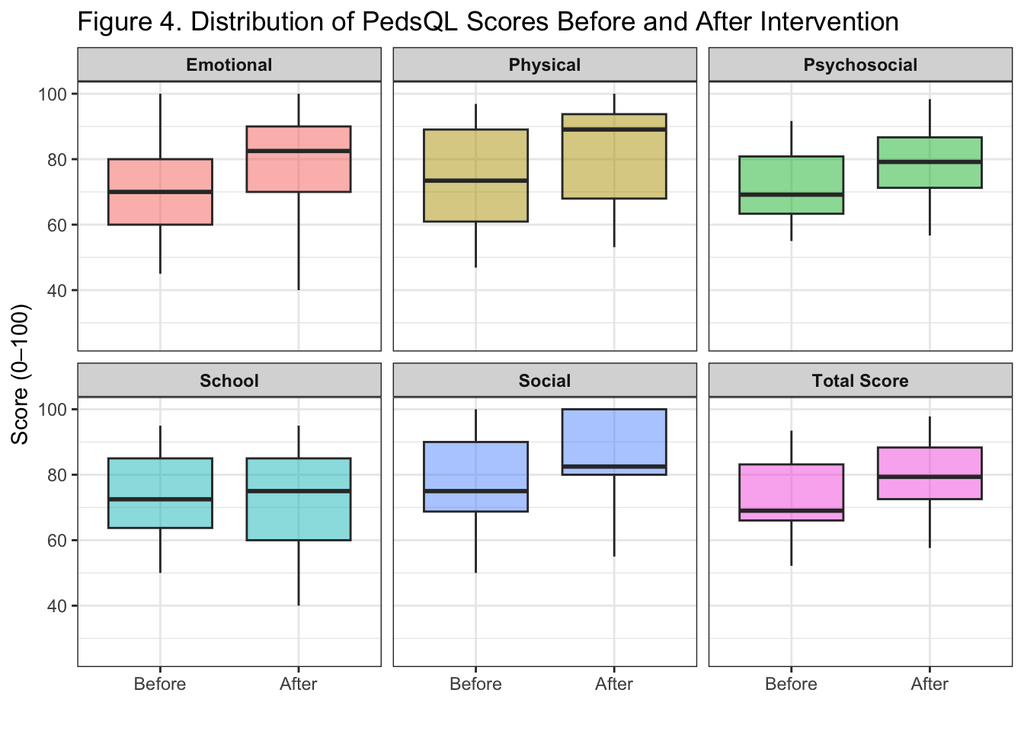

```r
library(dplyr)
library(tidyr)
library(ggplot2)

# Data PedsQL before/after
pedsql_data <- included_data %>%
  select(
    pedsql_totalself_before, pedsql_totalself_after,
    pedsql_physiqueself_before, pedsql_physiqueself_after,
    pedsql_emotionself_before, pedsql_emotionself_after,
    pedsql_relationself_before, pedsql_relationself_after,
    pedsql_ecoleself_before, pedsql_ecoleself_after,
    pedsql_psycosocialself_before, pedsql_psycosocialself_after
  ) %>%
  pivot_longer(cols = everything(),
               names_to = "Variable",
               values_to = "Score") %>%
  mutate(
    Time = ifelse(grepl("before", Variable), "Before", "After"),
    Time = factor(Time, levels = c("Before", "After")),
    Dimension = case_when(
      grepl("total", Variable) ~ "Total Score",
      grepl("physique", Variable) ~ "Physical",
      grepl("emotion", Variable) ~ "Emotional",
      grepl("relation", Variable) ~ "Social",
      grepl("ecole", Variable) ~ "School",
      grepl("psycosocial", Variable) ~ "Psychosocial"
    )
  )

# Plot

p_pedsql <- ggplot(pedsql_data, aes(x = Time, y = Score, fill = Dimension)) +

  geom_boxplot(alpha = 0.5, outlier.shape = NA) +

  facet_wrap(~ Dimension, nrow = 2) +

  xlab("") +
  ylab("Score (0–100)") +
  ggtitle("Figure 4. Distribution of PedsQL Scores Before and After Intervention") +

  theme_bw() +
  theme(
    strip.text = element_text(face = "bold"),
    legend.position = "none"
  )
p_pedsql
```

```r
# Export
ggsave(
  "../figures/Figure_4_PedsQL_Before_After.png",
  plot = p_pedsql,
  width = 8,
  height = 6
)
```

# Step 11. Physical performance correlation – quality of life

The association between functional capacity and quality of life was assessed using Spearman’s rank correlation coefficient, due to the non-normal distribution of the data.

The analysis was performed between 6-minute walk distance and PedsQL score.

```r
# Spearman correlation
cor_test <- cor.test(
  included_data$`6minwt_distance_traveled_m_after`,
  included_data$pedsql_totalself_after,
  method = "spearman"
)

cor_test
```

```
##
##  Spearman's rank correlation rho
##
## data:  included_data$`6minwt_distance_traveled_m_after` and included_data$pedsql_totalself_after
## S = 1081.3, p-value = 0.4299
## alternative hypothesis: true rho is not equal to 0
## sample estimates:
##       rho
## 0.1869827
```

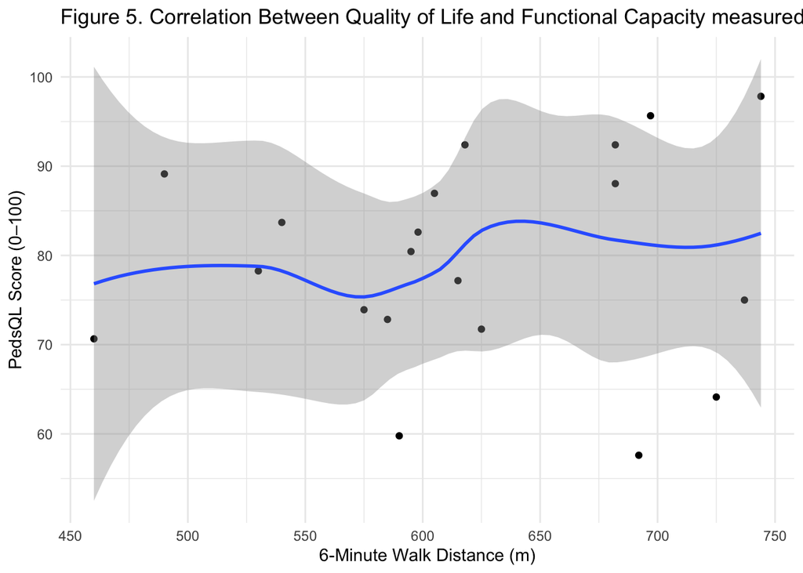

```r
# Export Spearman correlation results
sink("../results/spearman_correlation_results.txt")
cat("Spearman correlation (6MWT vs PedsQL)\n\n")
print(cor_test)
sink()

# Viewing
library(ggplot2)

# Create plot
p_corr <- ggplot(included_data, aes(
  x = `6minwt_distance_traveled_m_after`,
  y = pedsql_totalself_after
)) +
  geom_point() +
  geom_smooth(method = "loess", se = TRUE) +
  xlab("6-Minute Walk Distance (m)") +
  ylab("PedsQL Score (0–100)") +
  ggtitle("Figure 5. Correlation Between Quality of Life and Functional Capacity measured at 6mwt ") +
  theme_minimal()

p_corr
```

```r
# Export PDF
ggsave(
  "../figures/Figure_5_Correlation_PedsQL_6MWT.png",
  plot = p_corr,
  width = 8,
  height = 6
)
```